# ECON 490 - Applied Machine Learning in Economics Problem Set 4 (100pts) - due date: Thursday, April 21

Adam Wawrowski (adamw4)

4/21/2022

# Answer 1

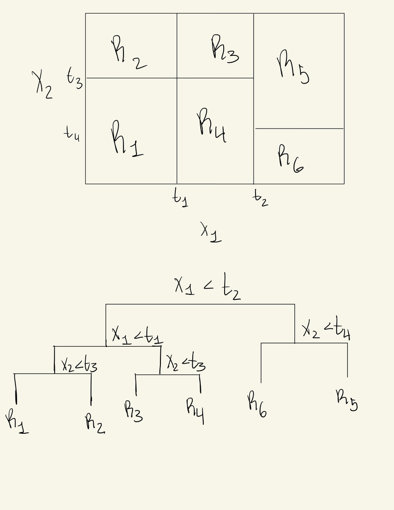

# Answer 2

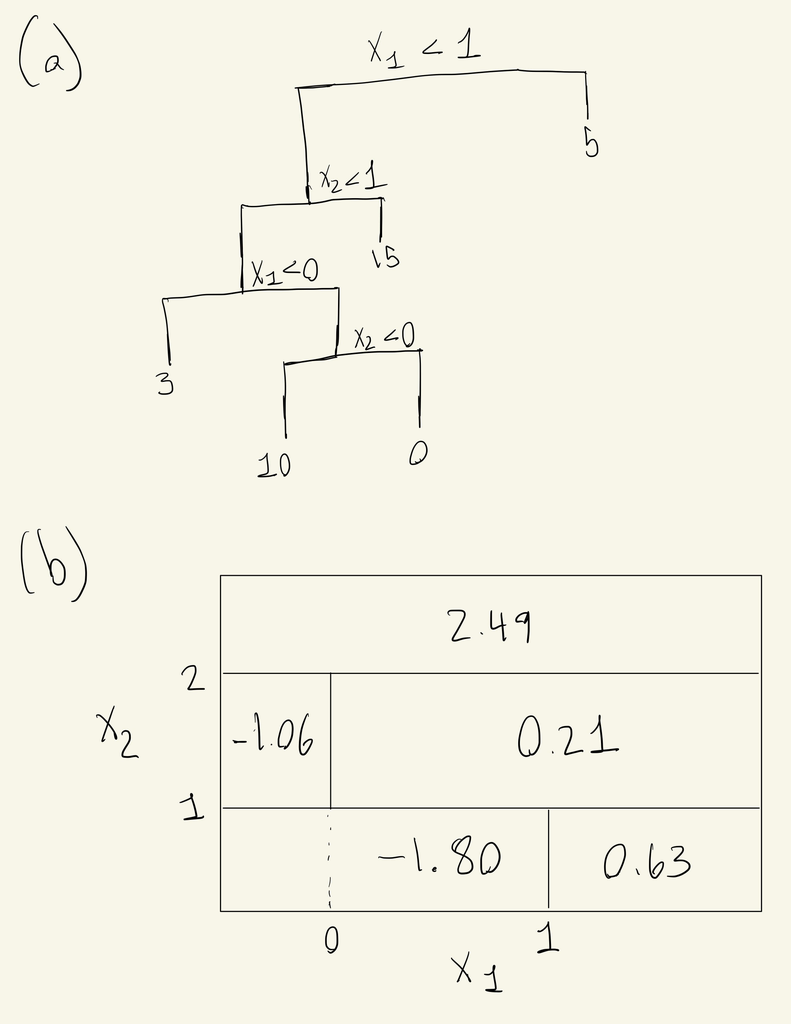

# Answer 3

When considering the majority vote approach, we must classify each estimate separately, and then we can combine each estimate by its classification. We know that:
$$\begin{aligned}
P(\text{Class is Red}\mid X) > 0.50 \implies P(\text{Class is Red}\mid X) > P(\text{Class is Green}\mid X)
\end{aligned}$$
With this, we find that 6 out of 10 estimates classify that the class is red. Our final prediction of the class is Red.

When considering the average probability approach, we must take the average of the estimates.

$$\begin{aligned}
P_{avg}(\text{Class is Red}\mid x) = \frac{1}{n}\sum^n P(\text{Class is Red}\mid x) = 0.45\\
P_{avg}(\text{Class is Green}\mid x)=0.55
\end{aligned}$$
Our final prediction is that the class is Green.

# Answer 4

First, we find an initial model using recursive binary splitting on the data. Through this process, the data is converted into a tree using a top-down, greedy approach.

Next, we using complexity pruning to find a set of best subtrees. In order to find the best tree in this set, we have to find an $\alpha$ such that the MSE is lowest.

In order to find $\alpha$, we use k-fold Cross-Validation. Once we have $\alpha$, we can evaluate the complexity of the tree that minimizes Test MSE.

# Answer 5

```r
set.seed(1)
train = sample(nrow(Carseats),nrow(Carseats)/2)
d.train = Carseats[train,]
test = Carseats[-train,"Sales"]
```

```r
tree.carseats <- tree(Sales ~ ., data = Carseats, subset = train)
summary(tree.carseats)
```

```
##
## Regression tree:
## tree(formula = Sales ~ ., data = Carseats, subset = train)
## Variables actually used in tree construction:
## [1] "ShelveLoc"   "Price"       "Age"         "Advertising" "CompPrice"
## [6] "US"
## Number of terminal nodes:  18
## Residual mean deviance:  2.167 = 394.3 / 182
## Distribution of residuals:
##     Min.  1st Qu.   Median     Mean  3rd Qu.     Max.
## -3.88200 -0.88200 -0.08712  0.00000  0.89590  4.09900
```

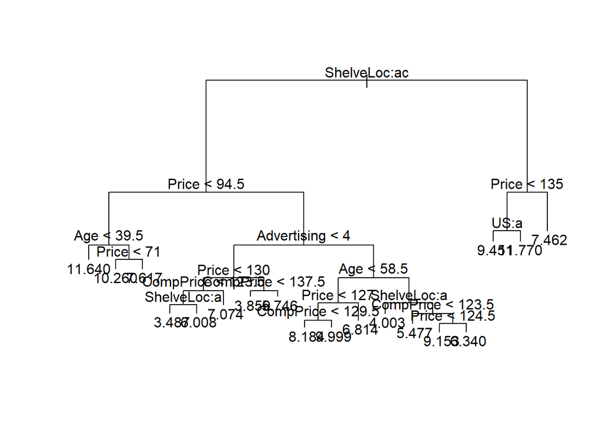

```r
plot(tree.carseats)
text(tree.carseats)
```

```r
tree.pred <- predict(tree.carseats, Carseats[-train, ])
mean((Carseats[-train, 'Sales'] - tree.pred) ^ 2)
```

```
## [1] 4.922039
```

3. Now we run cross-validation on the tree.

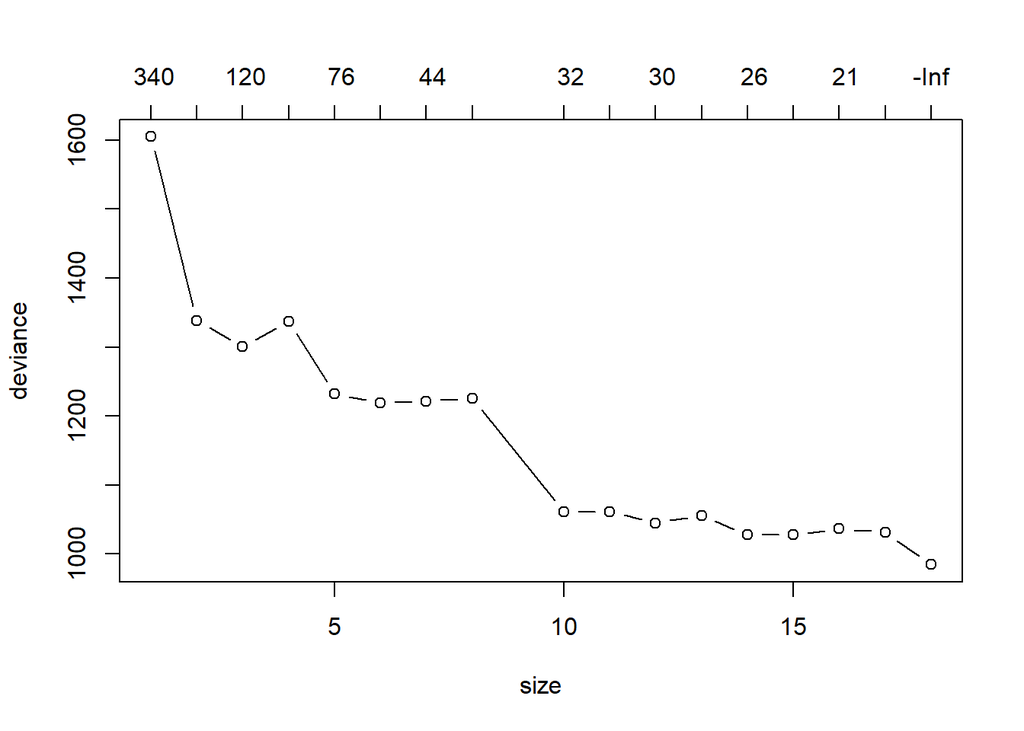

```r
set.seed(1)
cv.carseats=cv.tree(tree.carseats)
plot(cv.carseats, type = "b")
```

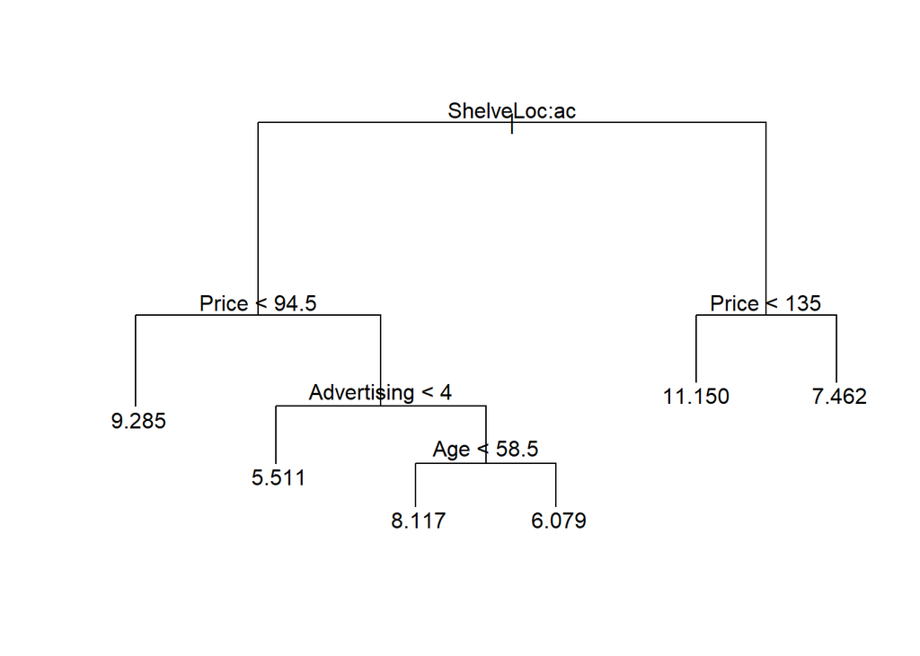

```r
prune.carseats = prune.tree(tree.carseats, best = 6)
plot(prune.carseats)
text(prune.carseats)
```

```r
tree.pred=predict(prune.carseats,Carseats[-train,])
mean((tree.pred-Carseats[-train,'Sales'])^2)
```

```
## [1] 5.318073
```

Pruning our tree actually increased the test MSE, so this approach is not feasible.

```r
x <- ncol(train) - 1
bag.car = randomForest(Sales~.,data = d.train, mtry = 10, importance = TRUE)
y.bag = predict(bag.car, newdata = Carseats[-train,])
mean((y.bag-Carseats[-train,]$Sales)^2)
```

```
## [1] 2.588149
```

```r
importance(bag.car)
```

```
##                %IncMSE IncNodePurity
## CompPrice   25.6142224    170.664874
## Income       4.5915046     91.047400
## Advertising 12.9597786     98.653166
## Population  -0.7823257     57.653647
## Price       55.2302897    510.311641
## ShelveLoc   48.5480002    381.630885
## Age         16.7267043    158.261715
## Education    0.9105144     43.460189
## Urban        0.2260420      9.347446
## US           5.8455044     18.261630
```

The most important variables are Price and ShelveLoc.

```r
set.seed(1)
rf.car = randomForest(Sales~ ., data = d.train, mtry = 3, importance = TRUE)
y.rf = predict(rf.car, newdata = Carseats[-train,])
mean((y.rf - Carseats[-train,]$Sales)^2)
```

```
## [1] 2.960559
```

Our test MSE is 2.960559, which is lower than our first tree, but not as much of an improvement as the bagging approach.